# Module 1 — Exploratory Analysis and Quality Control

BBCC2026 Tutorial: Do the Samples Look the Way We Expect Before We Test Anything?

Francesco Cecere** · *Senior Bioinformatic Researcher* · AORN Santobono-Pausilipon IRCCS

Eva Luna Tarallo** · *Junior Bioinformatic Researcher* · AORN Santobono-Pausilipon IRCCS

18 ottobre 2026

# From Module 0

Module 0 load the TARGET-WT (Wilms tumor) expression matrix and clinical sheet (`data/sample_metadata.csv`): 124 samples, 82 **favorable** and 42 **unfavorable** histology. Before we compare groups statistically in Module 2, this module asks a more basic question: **do the samples themselves look ok?** Quality control is not a formality, an unnoticed outlier sample, batch effect, or mislabeled group can produce a “biomarker” that is really just a technical artifact.

**Session plan:** recap & reload the data → library sizes → PCA, explained and plotted → sample-sample correlation → pediatric QC.

```r
counts_raw <- read_csv(
  "data/TARGET_WT_gene_expression_tpm.csv",
  show_col_types = FALSE
) %>%
  rename(gene_symbol = gene_name)

sample_metadata <- read_csv("data/sample_metadata.csv", show_col_types = FALSE)
```

```r
counts_long <- counts_raw %>%
  pivot_longer(-gene_symbol, names_to = "case_submitter_id", values_to = "tpm") %>%
  left_join(sample_metadata, by = "case_submitter_id")
```

# TPM Sum Sanity Check per Sample

Unlike raw counts, **TPM values are already normalized so that every sample’s protein-coding genes sum to approximately the same total**, that is what “transcripts per million” means by construction.

**Beginner note — how TPM is computed.** For gene $i$ in a given sample, with $X_i$ reads mapped to it and an effective transcript length $\ell_i$ (in kilobases), TPM is built in two steps:

$$\text{RPK}_i = \frac{X_i}{\ell_i}
\qquad\qquad
\text{TPM}_i = \frac{\text{RPK}_i}{\sum_j \text{RPK}_j} \times 10^6$$

1. **Divide by gene length first** (reads per kilobase, RPK): a long gene collects more reads than a short one at the same expression level, so this removes the length bias.
2. **Then divide by the sample’s total RPK and multiply by one million**: this removes the sequencing-depth difference between samples, so every sample is put on the same scale.

The consequence is built into the formula: summed over **all** genes, every sample’s TPM adds up to exactly $10^6$. Our matrix keeps only **protein-coding** genes (non-coding RNAs, pseudogenes etc. were dropped when the data were assembled), so here each sample sums to somewhat *less* than one million, the missing part is exactly the non-protein-coding share of that sample’s transcripts.

This gives us a cheap, different sanity check than a traditional library-size plot: instead of expecting variation, **we expect near-constancy**, and a sample that deviates noticeably from the rest is the one worth flagging (degraded RNA, a processing anomaly).

```r
library_sizes <- counts_long %>%
  group_by(case_submitter_id, histologic_subtype) %>%
  summarise(total_tpm = sum(tpm), .groups = "drop") %>%
  arrange(total_tpm)
```

| min | median | max |
| --- | --- | --- |
| 820618 | 915475 | 937766 |

[interactive chart not shown]

# Principal Component Analysis

PCA summarizes genome-wide variation into a small number of orthogonal axes. If favorable and unfavorable samples separate cleanly along the top components, histology is a major driver of overall transcriptional variation; if they do not, histology differences (if any) are more subtle than other sources of variability (batch, individual variation, etc.).

```r
# Filter out very low-expressed genes before PCA: near-constant, low-TPM
# genes contribute mostly noise to variance-based methods like PCA.
gene_mean_expr <- counts_long %>%
  group_by(gene_symbol) %>%
  summarise(mean_tpm = mean(tpm), .groups = "drop")

genes_to_keep <- gene_mean_expr %>% filter(mean_tpm >= 1) %>% pull(gene_symbol)

# Build a genes x samples matrix of log2-transformed, filtered TPM for PCA.
expr_matrix_wide <- counts_long %>%
  filter(gene_symbol %in% genes_to_keep) %>%
  mutate(log2_tpm = log2(tpm + 1)) %>%
  select(gene_symbol, case_submitter_id, log2_tpm) %>%
  pivot_wider(names_from = case_submitter_id, values_from = log2_tpm)

expr_matrix <- as.matrix(expr_matrix_wide[, -1])
rownames(expr_matrix) <- expr_matrix_wide$gene_symbol

# PCA is computed on samples (rows = samples), hence the transpose.
pca_result <- prcomp(t(expr_matrix), scale. = FALSE)

pca_scores <- as_tibble(pca_result$x, rownames = "case_submitter_id") %>%
  left_join(sample_metadata, by = "case_submitter_id")

variance_explained <- tibble(
  PC = paste0("PC", seq_along(pca_result$sdev)),
  variance_explained_pct = round(100 * pca_result$sdev^2 / sum(pca_result$sdev^2), 2)
)
```

| PC | variance_explained_pct |
| --- | --- |
| PC1 | 21.26 |
| PC2 | 9.53 |
| PC3 | 5.43 |
| PC4 | 4.2 |
| PC5 | 3.41 |
| PC6 | 3.24 |
| PC7 | 2.69 |
| PC8 | 2.29 |
| PC9 | 1.94 |
| PC10 | 1.78 |

[interactive chart not shown]

# Sample-Sample Correlation

As a second, complementary view of sample structure, we compute pairwise Pearson correlations between all samples on the same filtered, log2-transformed matrix. Samples from the same histology are expected to correlate more strongly with each other than with samples from the other group; a sample that correlates poorly with everyone (including its own group) is a candidate outlier worth flagging.

```r
# Compute the full sample-by-sample correlation matrix.
sample_cor_matrix <- cor(expr_matrix, method = "pearson")
```

In the heatmap below, samples are **clustered** (the tree on top): samples with similar expression profiles are placed next to each other, so groups of similar samples show up as bright blocks and outliers as dark stripes. The colored bars show each sample’s histology. The diagonal (each sample with itself, always 1) is left blank.

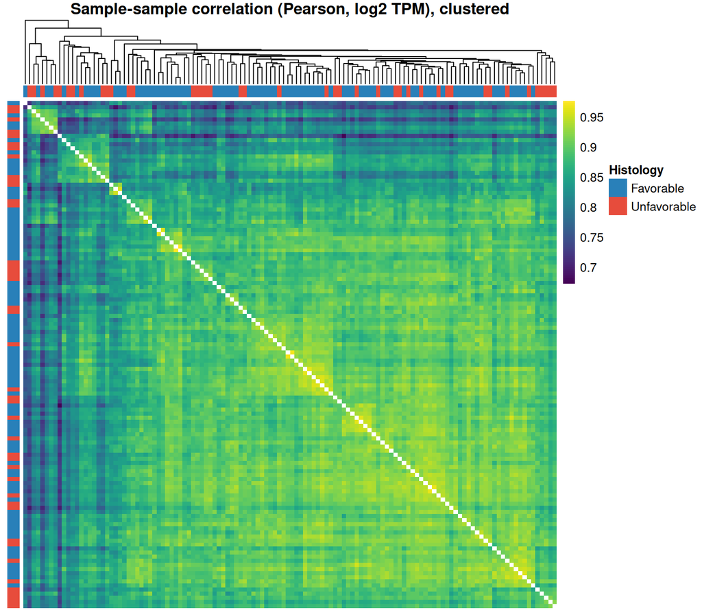

To find individual outliers, it is easier to summarize each sample with one number: its **median correlation with all other samples**. A sample far below the rest of its group is the one worth flagging. Hover a point to see its ID.

```r
median_cor <- tibble(
  case_submitter_id  = rownames(heatmap_matrix),
  median_correlation = apply(heatmap_matrix, 1, median, na.rm = TRUE)
) %>%
  left_join(sample_metadata, by = "case_submitter_id")
```

[interactive chart not shown]

# Why QC Is Non-Negotiable in Pediatric Data

- **Small n means every sample carries weight.** In a rare pediatric tumor cohort of, say, 15–20 patients, one undetected outlier sample (degraded RNA, contamination, mislabeling) can visibly shift a PCA plot and materially change a differential expression result — the same outlier would be statistically invisible in a 500-sample adult cohort.
- **Batch effects are a constant threat in multi-site pediatric consortia.** Rare disease and pediatric cancer studies frequently pool samples across hospitals and sequencing runs out of necessity, since no single center sees enough cases alone. PCA and correlation heatmaps are the first line of defense for spotting a batch masquerading as a biological signal.
- **QC decisions must be documented, not silently applied.** Removing an “outlier” sample changes the very small denominator a pediatric study is built on, so, any exclusion should be justified explicitly in the methods, exactly as the filtering and matching decisions were logged in Module 0 and this module.

Generated on 18 ottobre 2026 · Francesco Cecere (Senior Bioinformatic Researcher) · Eva Luna Tarallo (Junior Bioinformatic Researcher) · AORN Santobono-Pausilipon IRCCS